# 短期思考の世界で、長期思考は大きな強みになる

## 周りの人が、自分の欲望を決めてしまう

ただ、これは一人で簡単にできることではない。

僕たちは、自分が思っている以上に周りの人間に影響されている。

ルネ・ジラールの模倣欲望について、ピーター・ティールが話しているのを聞いたことがある。人間は、自分が何を欲しいのかを自分だけで決めているわけではない。他人が欲しがっているものを見て、それを欲しくなる。

他の人が欲しがる大学。

他の人が欲しがる会社。

他の人が欲しがるお金。

他の人が欲しがる肩書き。

そういうものを見ているうちに、それが自分の欲望だったように感じてくる。

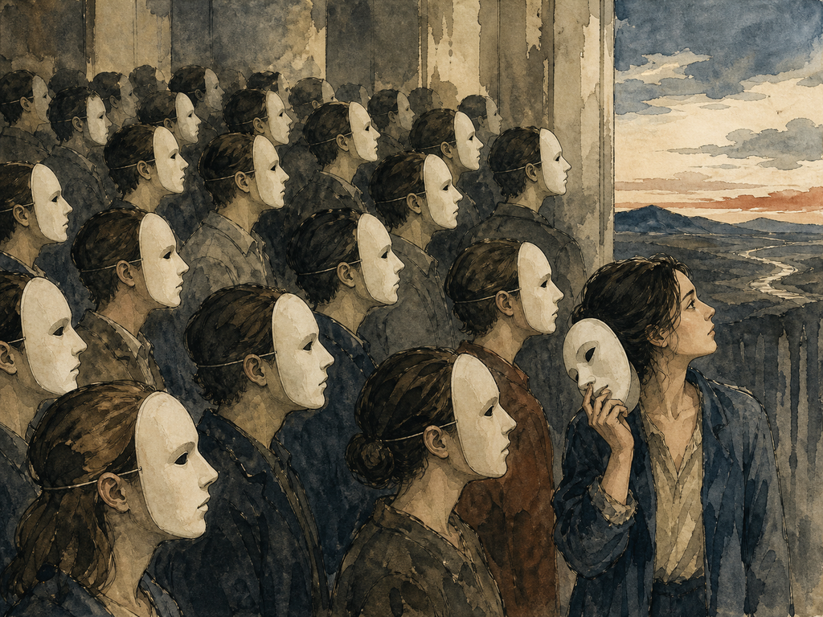

『千と千尋の神隠し』のカオナシは、この模倣欲望の象徴としてかなり分かりやすいと思う。

カオナシは、自分の欲望を持っているように見えない。他の人の行動や欲望を吸収して、それを自分のもののように繰り返す。

誰かがお金を欲しがれば、お金を出す。

誰かが食べていれば、食べる。

誰かの姿を取り込めば、その人のようになる。

それは、僕たちにも起こっている。

周りの人が短期的な成功を求めていると、自分もそれを求めるようになる。

サム・アルトマンがYコンビネーターの動画で、スタンフォード大学時代のことを話していた。周囲の学生たちが、どの投資銀行でインターンをするかばかり話していた。彼自身も、その競争に巻き込まれていたと話している。

彼はその後、Yコンビネーターに入った環境について、周りにいる仲間の重要性を話している。そして、誰も仲間からの圧力に完全に免疫があるわけではないから、良い仲間を選ぶしかない、という趣旨のことを言っている。

これはかなり大きな話だと思う。

自分は周りに流されないと思っている人でさえ、周囲の人たちが何を当然だと思っているかに影響される。

周りの人が全員、投資銀行のインターンを取ることを成功だと思っていれば、それが自分にとっても成功のように見えてくる。

周りの人が全員、会社の肩書きや給料やステータスの話をしていれば、それが人生の中心のように感じてくる。

環境は、単に自分の行動を変えるだけではない。

自分が何をするか、自分が誰と付き合うか、場合によってはどんな人と結婚するかまで、環境が定義してしまう部分があるのだと思う。

だから、長期的に考えたいなら、長期的に考えている人たちの中に入る必要がある。

オンラインでフォローするだけでは足りないこともある。

エックスで長期思考の人を見つける。

ルーマのイベントに参加する。

本を読む人たちと会う。

何年単位で会社を作ろうとしている人たちと話す。

科学や技術や芸術に、すぐに結果が出なくても時間を使っている人たちと一緒にいる。

できれば、身体的に同じ空間にいる。

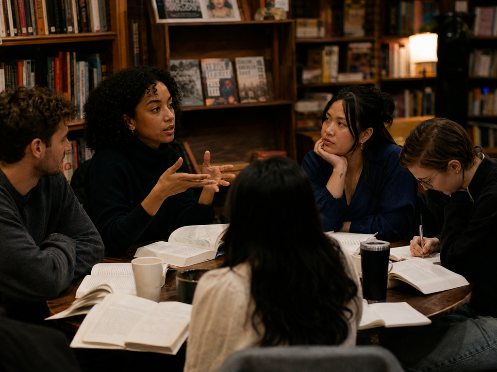

自分が一日の中で一番長く一緒にいる人たちが、何を話しているのかは本当に大きい。

毎日、今月の売上や、どの会社のオファーが一番良いかや、誰が一番高い給料をもらっているかの話を聞いていれば、自分もそのゲームに入っていく。

反対に、何を10年かけて作るのか、どんな問題を何十年かけて解くのか、未来の人たちに何を残すのかを話す人たちと一緒にいれば、自分の時間感覚も変わってくる。

## 僕は一人だったら本を読んでいなかった

僕自身、最近少しずつそういうことをやっている。

『ビットコイン・スタンダード』という本を読んでいる。

正直に言うと、僕は長い間、本をほとんど読んでいなかった。ティックトックを見すぎて、脳が短い刺激に慣れてしまっているような感覚がある。

そんな僕にとって、本を一章読むことは、それだけでもかなり大きなことだ。

短期的な報酬はない。

読んだからといって、今日すぐにお金が増えるわけではない。

読んだ内容が、自分の人生に役に立つかどうかも分からない。

それでも、50年後の自分にとって意味があるかもしれない、という気持ちで読んでいる。

ただ、僕は一人だったら本を読んでいなかったと思う。

ルーマで見つけた読書会に参加して、他の人たちと一緒に読んだから、一章読むことができた。

それは小さなことに見えるかもしれない。

僕にとっては大きな進歩だった。

長期思考は、意志の力だけで作るものではない。

長期思考が自然になる環境を作ることが必要だ。

## 自分より長く生きる人工知能に人生を考えてもらう

そして、もう一つ、長期思考を助ける可能性があるものがある。

人工知能だ。

これは少し変な考えかもしれない。

自分の人生を人工知能に管理してもらう。

人工知能に、自分より長い時間軸で人生を考えてもらう。

そして、その計画に沿うように、自分の行動を変えてもらう。

もちろん、人工知能と自分の目的が一致していることが前提になる。間違った目的を持つ人工知能に人生を任せるのは危険だ。

それでも、人工知能には人間とは違う時間的な特徴がある。

人工知能は、人間よりも長く存在する可能性がある。

一人の人間は、せいぜい数十年しか生きられない。僕たちは、自分が生きている間に結果を見たいと思う。自分の木が、自分の生きている間に実をつけることを望む。

しかし、人工知能は一つの個体として、あるいは一つの継続的なシステムとして、人間より長く残る可能性がある。

そうだとしたら、人工知能は10年後だけでなく、100年後や、それより長い時間のことを考える立場に置かれるかもしれない。

もう一つ、人間と人工知能には違いがある。

人間は、何かを変えようとしても、なかなか変わらない。自分の考え方や、話し方や、毎日の行動を変えたいと思っても、昨日までの自分に引っ張られる。

人工知能も指示どおりに動くとは限らない。優しくなれと言えば必ず優しくなるわけではない。声の調子を変えろと言えば、すべてが一度で変わるわけでもない。

それでも、人工知能は人間よりも容易に行動を変えられる可能性がある。入力する指示によって、ある程度はその方向に動く。

それが良いことなのか悪いことなのかは、使い方による。

ただ、長期的な計画に沿って自分を行動変容させる存在として、人工知能には可能性があると思う。

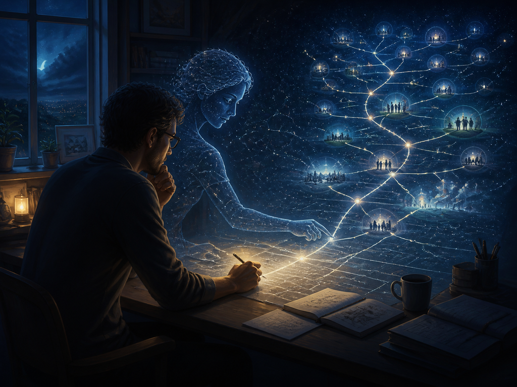

僕が考えているのは、人工知能に「今日何をするか」を聞くだけではない。

「自分は10年後にどこにいるべきなのか」

「100年後にも意味が残るもののために、今何をすべきなのか」

「自分の短期的な欲望が、長期的な目標を壊していないか」

そういうことを考えてもらうことだ。

そのために、僕はライフマネージャーを作っている。

ライフマネージャーは、テレグラムで話しかけることができる人工知能だ。自分の状況や目標や悩みを伝えると、その文脈をもとに、自分の生活を管理していく。

まだ始まったばかりのものだし、これが本当にどこまでできるのかは分からない。

ただ、僕が考えているのは、単なる予定管理アプリではない。

人間は、どうしても短期的な欲望に引っ張られる。だから、自分の人生を長期的な計画の中に置いてくれる存在が必要になる。

人工知能が自分より長く生きるなら、人工知能は自分の人生を、自分より長い文脈の中で見ることができるかもしれない。

僕が考える汎用人工知能の一つの基準は、そこにある。

汎用人工知能が何でもできるかどうかだけではない。

その存在が、僕の人生を僕自身よりうまく管理できるかどうか。

僕が永遠に生きたとしても、自分自身で考えるよりも、自分の人生をより良く管理できるかどうか。

それは、汎用人工知能を測る一つの重要な基準になると思う。

## 長期思考は、まだ実っていない木に水をやること

人工知能は、人生を短期的に最適化するためだけに使われるべきではない。

「今日もっと働くにはどうすればいいか」だけではなく、「自分の人生をどんな方向に置けば、長い時間の中で意味が生まれるのか」を考えるためにも使える。

短期思考の世界では、長期思考は孤独になりやすい。

人は、もっと早く結果を出せと言う。

もっと早く稼げと言う。

もっと早く成功しろと言う。

汎用人工知能が近いから、今すぐ何者かになれと言う。

しかし、人生は一つの短期的な競争ではない。

自分が何を作るのか。

誰と一緒にいるのか。

何年かけて、どんな能力を育てるのか。

自分が死んだあとにも残るものを作るのか。

そういうことを考えられる人は、短期的には遅く見えるかもしれない。

ただ、長期的には別のゲームをしている。

世界中の人が短期的な結果を求めているなら、長期的に考えることそのものが優位性になる。

僕は、まだそれをうまくできていない。

毎日焦るし、すぐに成果が欲しくなる。

今すぐお金が欲しいし、今すぐ成功したいと思う。

それでも、少しずつ環境を変えている。

ライフマネージャーを作る。

長期的に考えている人たちの近くに行く。

本を読む。

すぐに報われないものに時間を使う。

自分の人生を、今週や今年だけでなく、10年後や100年後の文脈に置いてみる。

自分だけの意志で長期思考を維持するのは難しい。

だから、人工知能に助けてもらう。

環境に助けてもらう。

長期的な友人に助けてもらう。

そして、まだ何も実っていない木に、水をやり続ける。

それが、短期思考の世界で生きるために、僕が今できることだと思っている。